# Data from: Response of bluebunch wheatgrass to invasion differences in competitive ability among invader-experienced and naïve populations

Jeff Walker

2019-03-06

# Sources

Gibson A, Nelson CR, Atwater DZ (2018) Response of bluebunch wheatgrass to invasion: Differences in competitive ability among invader-experienced and invader-naïve populations. Functional Ecology 32(7): 1857-1866. https://doi.org/10.1111/1365-2435.13090

Gibson AL, Nelson CR, Atwater DZ (2018) Data from: Response of bluebunch wheatgrass to invasion: differences in competitive ability among invader-experienced and naïve populations. Dryad Digital Repository. https://doi.org/10.5061/dryad.j75g369

# Summary

# Caveats

Failure to reproduce or partial reproducibility might be an error in my coding, or my misunderstanding of the author’s methods, or my lack of knowledge of statistics generally or the R functions that I use more specifically.

# Setup

```r
library(ggplot2)
library(readxl)
library(data.table)
library(emmeans)
library(nlme)
library(lmerTest)
library(car)
library(doBy)
library(plyr)
library(cowplot)
```

```r
data_folder <- "../data"
folder <- "Data from Response of bluebunch wheatgrass to invasion- differences in competitive ability among invader-experienced and naïve populations"

# images need to be moved to /static/images/data from.../image.png
knitr_path <- TRUE # run = TRUE to debug

source("../R/clean_label.R") # bookdown
```

# Import

```r
fn <- "Gibson_invasion_response_data.xlsx"
file_path <- paste(data_folder, folder, fn, sep="/")

sheet_i <- "Germination"
exp1 <- data.table(read_excel(file_path, sheet=sheet_i))
colnames(exp1) <- clean_label(colnames(exp1))
setnames(exp1, "Type", "Experience")

sheet_i <- "Traits"
exp2 <- data.table(read_excel(file_path, sheet=sheet_i, na="x"))
colnames(exp2) <- clean_label(colnames(exp2))
exp2[, Treatment:=factor(Treatment)]
exp2[, Experience:=factor(Population_Type)]
exp2[, Stage:=ifelse(as.character(Date)=="2012-04-30","Seedling", "Juvenile")]
exp2[, Exp_Pop:=factor(paste(Experience,Population,sep="."))]
```

check consistancy of populations, for example the data have both LHP and LHP#1, are these the same? different?

```r
n_seed <- exp2[!is.na(Longest_leaf) & Stage=="Seedling", .(N=.N), by=.(Treatment, Experience, Population)]
n_seed_wide <- dcast(n_seed, Experience + Population ~ Treatment, value.var="N")
orderBy(~ Population + Experience, data=n_seed_wide)
```

```
##     Experience Population C  T
##  1:          E        BLK 5 NA
##  2:          N        BLP 5 NA
##  3:          N         HP 5  5
##  4:          E        LHK 5 NA
##  5:          N        LHP 5  5
##  6:          N      LHP#1 5  3
##  7:          E       LNFK 5  5
##  8:          E       MCLK 5  5
##  9:          N       MCLP 5  3
## 10:          N        MJP 5  5
## 11:          E        MMK 5  5
## 12:          N        MMP 5  5
## 13:          E        PTK 5  3
## 14:          N        PTP 5  5
```

```r
n_juv <- exp2[!is.na(Longest_leaf) & Stage=="Juvenile", .(N=.N), by=.(Treatment, Experience, Population)]
n_juv_wide <- dcast(n_juv, Experience + Population ~ Treatment, value.var="N")
orderBy(~ Population + Experience, data=n_juv_wide)
```

```
##     Experience Population C  T
##  1:          N        Ana 5  3
##  2:          E        BLK 5  3
##  3:          N        BLP 5  1
##  4:          N         HP 5  5
##  5:          E        LHK 5  2
##  6:          N        LHP 5  5
##  7:          N      LHP#1 5  1
##  8:          E       LNFK 5  5
##  9:          E       MCLK 5  3
## 10:          N       MCLP 5 NA
## 11:          N        MJP 5  2
## 12:          E        MMK 5  5
## 13:          N        MMP 5  5
## 14:          E        PTK 5  3
## 15:          N        PTP 5  1
```

```r
# orderBy(~ Experience + Population, data=n_juv_wide[Population!="Ana"])
```

Inconsistencies

1. Given the Source Population tab in the excel file, there is no obvious interpretation of LHP v LHP#1. The tab has this as LHP1 and it doesn’t look like LHP is something else. Note that in Fig. 2a there is “LH” and “LH#2” - these are probably “LHP” and “LHP#1” (note that the K and P are dropped from the labels in Fig 2). But this raises the question why there are two “Populations” from the same place? One answer is in Supplement 2, which confirms there are two LHP pops but it calls these “LH” and “LH#2”. Given sample size, LHP#1 (from data) = LHP#2 from supplement and in Fig 2.
2. Ana is coded Experience=“C” in some rows and “N” in other rows. In the Source Populations tab it is coded “C”

```r
subdata <- function(dt, stage_j, xcols, y, min_n=2){
  # this is a function used several times so making a function out of it
  # stage_j is the stage
  # xcols is the vector of labels of the columns of factors for the model
  # y is the response column label
  # min_n is the minimum n to include in the subdata

  #first get populations with n>1 in Treatment="T"
  n_pops <- dt[Stage==stage_j &
                 !is.na(get(y)) &
                 Population != "Ana", .(n=.N), by=.(Population)]
  inc <- n_pops[n >= (5+min_n), Population] # all Treatment="C" have n=5

  # reduce to only relevant columns, stage, and delete Ana
  subdata_i <- na.omit(dt[Stage==stage_j & Population %in% inc, .SD, .SDcols=c(xcols, y)])

  # recode Populations to 1:n_pop; this is only way to analyze as fixed using aov
  # subdata[, Population2:=Population]
  popsE <- unique(subdata_i[Experience=="E", Population])
  subdata_i[Population %in% popsE, Population.cross:= mapvalues(Population, from = popsE, to = as.character(1:length(popsE)))]
  popsN <- unique(subdata_i[Experience=="N", Population])
  subdata_i[Population %in% popsN, Population.cross:= mapvalues(Population, from = popsN, to = as.character(1:length(popsN)))]
  subdata_i[, Population.cross:=factor(Population.cross)]

  return(subdata_i)
}
```

# Reproducibility

## Table 1

### Methods

> Next, we assessed trait variation among populations of the same experience type, between invader experience groups (IE and IN) and between treatments using general linear contrasts with population as a fixed factor nested in experience type and with separate models for each response variable (length of longest leaf, number of leaves, total biomass, shoot biomass, root biomass and root:shoot ratio) at each growth phase (seedling and juvenile); models allowed for unequal variance by population type (Pinheiro, Bates, DebRoy, Sarkar, & Team, 2012). Population was nested in experience type because each population was either IE or IN. Anatone was excluded from this analysis. We excluded four native populations from seedling trait analysis and three from juvenile trait analysis because there were not enough plants available from treatment pots.

Two issues for reproducibility: 1) the model is not clear (see below) and 2) The reported sample sizes are smaller than in the provided Excel file and I cannot details on which cases were excluded.

### Check on balance

```r
exp2.b <- exp2[!is.na(Longest_leaf) & Population!="Ana",]
counts <- exp2.b[, .(N=.N), by=.(Treatment, Experience, Population, Stage, Exp_Pop)]
exp2.b <- merge(exp2.b, counts, by=c("Treatment", "Experience", "Population", "Stage", "Exp_Pop"))
```

The data are unbalanced at two levels: 1) Different cell sizes in the Treatment x Experience table. There are 8 “N” popuilations but only 6 “E” populations. 2) Some populations, which is the nested factor but also determine E, are missing in the “T” level of Treatment.

```r
counts[, .(N=.N), by=.(Stage, Treatment, Experience)]
```

```
##       Stage Treatment Experience N
## 1: Seedling         C          E 6
## 2: Seedling         T          E 4
## 3: Seedling         C          N 8
## 4: Seedling         T          N 7
## 5: Juvenile         C          E 6
## 6: Juvenile         C          N 8
## 7: Juvenile         T          E 6
## 8: Juvenile         T          N 7
```

```r
counts2 <- counts[N>1, .(N=.N), by=.(Stage, Population, Treatment)]
counts2[, .(N=.N), by=.(Stage, Treatment)]
```

```
##       Stage Treatment  N
## 1: Seedling         C 14
## 2: Seedling         T 11
## 3: Juvenile         C 14
## 4: Juvenile         T 10
```

```r
# orderBy(~ Experience + Population, data=n_juv_wide[Population!="Ana"])
# orderBy(~ Experience + Population, data=n_juv_wide[Population!="Ana"])
```

Does this identify the 4 missing in Juvenile and 3 missing in Seedling?

```r
# change eval to TRUE to see these views
counts2[, .(N=.N), by=.(Stage, Population)]
unique(counts2[Treatment=="C" & Stage=="Seedling", Population])
unique(counts2[Treatment=="T" & Stage=="Seedling", Population])
sum(counts[Stage=="Seedling", N])
counts[, .(N=sum(N)), by=Stage]
```

### The model is unclear

> Next, we assessed trait variation among populations of the same experience type, between invader experience groups (IE and IN) and between treatments using general linear contrasts with population as a fixed factor nested in experience type

The authors use “general linear contrasts” a fixed nested ANOVA and cite the nlme package but do not specify any random effect and the ANOVA table suggests only fixed effects (because what other factor do they have that could be random?). Perhaps they used gls() to model unequal variances with Population as both a fixed effect and as the weights for heterogenous variances?. An issue with the data even for a complete fixed effects model `y ~ Treatment*Experience + Experience:Population`, which is a fixed Population nested within Experience, has a singular XtX^-1 covariance matrix, which creates problems.

```r
xcols <- c("Treatment", "Experience", "Stage", "Population", "Exp_Pop")
ycols <- c("Longest_leaf", "n_Leaves", "Biomass", "Root_biomass", "Shoot_biomass", "Root.shoot_ratio")

con3 <- list(Treatment=contr.sum, Experience=contr.sum) # change the contrasts coding for the model matrix

f_table <- list()
p_table <- list()
df_table <- list()
n_table <- list()
for(stage_j in c("Seedling", "Juvenile")){
  for(y in ycols){
    subdata_i <- subdata(exp2, stage_j, xcols, y, min_n=0)

    # the best I can do. I explicitly ordered the terms this way to match table 1

    fit3 <- lm(get(y) ~  Treatment + Experience + Population.cross%in%Experience + Treatment:Experience, contrasts=con3, data=subdata_i)

    table_i <- drop1(fit3, .~., test="F") # matches JMP except Experience row

    # these do not run because of singular xtxi matrix
    # Anova(fit3, type="3")
    # form_i <- formula(paste(y, "~ Treatment*Experience + Population.cross%in%Experience"))
    # fit <- gls(form_i, weights=varIdent(form=~1|Population), data=subdata_i) # singular

    if(y==ycols[1]){
      f_table[[stage_j]] <- data.table(terms=row.names(table_i)[2:5],
                            table_i[2:5, "F value"])
      p_table[[stage_j]] <- data.table(terms=row.names(table_i)[2:5],
                            table_i[2:5, "Pr(>F)"])
      df_table[[stage_j]] <- data.table(terms=c(row.names(table_i)[2:5], "n"),
                            c(table_i[2:5, "Df"], nrow(subdata_i)))
    }else{
      f_table[[stage_j]] <- cbind(f_table[[stage_j]], table_i[2:5, "F value"])
      p_table[[stage_j]] <- cbind(p_table[[stage_j]], table_i[2:5, "Pr(>F)"])
      df_table[[stage_j]] <- cbind(df_table[[stage_j]], c(table_i[2:5, "Df"], nrow(subdata_i)))
    }
    setnames(f_table[[stage_j]], old="V2", new=y)
    setnames(p_table[[stage_j]], old="V2", new=y)
    setnames(df_table[[stage_j]], old="V2", new=y)
  }
}
```

### Table 1–published

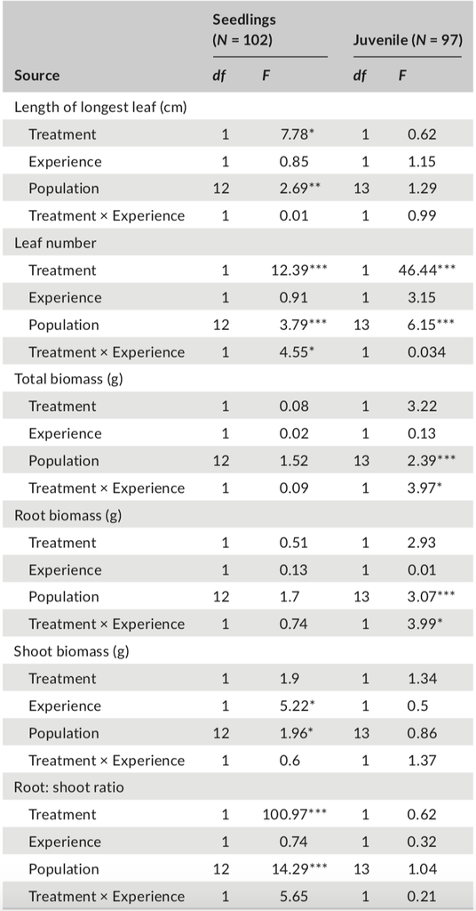

### Table 1 - repro

#### Seedling

df

| terms | Longest_leaf | n_Leaves | Biomass | Root_biomass | Shoot_biomass | Root.shoot_ratio |
| --- | --- | --- | --- | --- | --- | --- |
| Treatment | 1 | 1 | 1 | 1 | 1 | 1 |
| Experience | 1 | 1 | 1 | 1 | 1 | 1 |
| Experience:Population.cross | 12 | 12 | 12 | 12 | 12 | 12 |
| Treatment:Experience | 1 | 1 | 1 | 1 | 1 | 1 |
| n | 119 | 118 | 119 | 119 | 119 | 119 |

F-value

| terms | Longest_leaf | n_Leaves | Biomass | Root_biomass | Shoot_biomass | Root.shoot_ratio |
| --- | --- | --- | --- | --- | --- | --- |
| Treatment | 1.23 | 15.84 | 0.41 | 0.15 | 1.34 | 0.52 |
| Experience | 0.17 | 7.86 | 3.13 | 4.31 | 0.07 | 4.36 |
| Experience:Population.cross | 0.77 | 1.56 | 1.46 | 2.18 | 2.13 | 4.33 |
| Treatment:Experience | 0.68 | 0.75 | 0.24 | 0.41 | 0.02 | 0.05 |

P-value

| terms | Longest_leaf | n_Leaves | Biomass | Root_biomass | Shoot_biomass | Root.shoot_ratio |
| --- | --- | --- | --- | --- | --- | --- |
| Treatment | 0.270 | 0.000 | 0.522 | 0.700 | 0.250 | 0.471 |
| Experience | 0.679 | 0.006 | 0.080 | 0.040 | 0.786 | 0.039 |
| Experience:Population.cross | 0.676 | 0.114 | 0.151 | 0.018 | 0.021 | 0.000 |
| Treatment:Experience | 0.413 | 0.389 | 0.629 | 0.524 | 0.898 | 0.818 |

#### Juvenile

df

| terms | Longest_leaf | n_Leaves | Biomass | Root_biomass | Shoot_biomass | Root.shoot_ratio |
| --- | --- | --- | --- | --- | --- | --- |
| Treatment | 1 | 1 | 1 | 1 | 1 | 1 |
| Experience | 1 | 1 | 1 | 1 | 1 | 1 |
| Experience:Population.cross | 12 | 12 | 12 | 12 | 12 | 12 |
| Treatment:Experience | 1 | 1 | 1 | 1 | 1 | 1 |
| n | 111 | 111 | 111 | 111 | 111 | 111 |

F-value

| terms | Longest_leaf | n_Leaves | Biomass | Root_biomass | Shoot_biomass | Root.shoot_ratio |
| --- | --- | --- | --- | --- | --- | --- |
| Treatment | 0.57 | 10.31 | 0.90 | 0.26 | 1.50 | 0.16 |
| Experience | 3.17 | 5.51 | 0.02 | 0.02 | 0.29 | 0.10 |
| Experience:Population.cross | 0.97 | 4.32 | 2.52 | 3.26 | 0.89 | 1.40 |
| Treatment:Experience | 0.64 | 1.42 | 2.37 | 1.80 | 1.43 | 0.01 |

P-value

| terms | Longest_leaf | n_Leaves | Biomass | Root_biomass | Shoot_biomass | Root.shoot_ratio |
| --- | --- | --- | --- | --- | --- | --- |
| Treatment | 0.453 | 0.002 | 0.344 | 0.613 | 0.224 | 0.686 |
| Experience | 0.078 | 0.021 | 0.886 | 0.875 | 0.593 | 0.750 |
| Experience:Population.cross | 0.482 | 0.000 | 0.006 | 0.001 | 0.561 | 0.179 |
| Treatment:Experience | 0.425 | 0.236 | 0.127 | 0.183 | 0.235 | 0.922 |

**No F-values reproduce. The DF does not reproduce if I exclude 3 pops in the Seedling and 4 in the Juvenile anlaysis due to $n \le 1$. Excluding to populations with n > 1, the total N for Seedling and Juvenile is 104 and 88 (not 102, 97) The DF reproduces for Seedling only if I include all populations but DF does not reproduce for Juvenile (repro=12, published -=13) even if I include all populations. When I include all pops, the total N is 119 and 111. It’s not clear which cases are excluded from the analyses.**

## Figure 1

The SEs in the figure could be 1) modeled SE (my preference), 2) the raw SE pooling over replicates within Population (complete pool), or 3) the raw SE using the Population means. I compute all these but only plot the complete pooling SEs.

```r
xcols <- c("Treatment", "Experience", "Stage", "Population", "Exp_Pop")
ycols_seed <- c("Shoot_biomass", "n_Leaves", "Root.shoot_ratio")
ycols_juv <- c("n_Leaves","Biomass", "Root_biomass")

con3 <- list(Treatment=contr.sum, Experience=contr.sum) # change the contrasts coding for the model matrix

gg_list <- list()

for(stage_j in c("Seedling", "Juvenile")){
  if(stage_j=="Seedling"){
    ycols <- ycols_seed}else{
      ycols <- ycols_juv}
  for(y in ycols){
    subdata_i <- subdata(exp2.b, stage_j, xcols, y)

    # modeled SE
    fit3 <- lm(get(y) ~  Treatment + Experience + Population.cross%in%Experience + Treatment:Experience, contrasts=con3, data=subdata_i)
    fit3.emm <- data.table(summary(emmeans(fit3, specs=c("Treatment", "Experience"))))

    # raw SE (how to deal with nested?)
    # pooled SE (ignore nested structure)
    subdata.pool.SE <- subdata_i[, .(ybar=mean(get(y)),
                                   SE=sd(get(y))/sqrt(.N)
    ), by=.(Treatment, Experience)]
    # SE of pop means
    # no pool (average replicates within pop)
    subdata.nopool <- subdata_i[, .(ybar=mean(get(y))
    ), by=.(Treatment, Experience, Population)]
    subdata.nopool.SE <- subdata.nopool[, .(ybar=mean(ybar),
                                            SE=sd(ybar)/sqrt(.N)
    ), by=.(Treatment, Experience)]

    # modeled SE
    pd <- position_dodge(0.5)
    gg <- ggplot(data=fit3.emm, aes(x=Treatment, y=emmean, color=Experience, group=Experience)) +
      geom_point(position=pd) +
      geom_line(position=pd) +
      geom_errorbar(aes(min=emmean-SE, max=emmean+SE), position=pd, width=.2) +
      ylab(y) +
      NULL
    #gg

    # complete pooling
    gg <- ggplot(data=subdata.pool.SE, aes(x=Treatment, y=ybar, color=Experience, group=Experience, shape=Experience)) +
      geom_point(position=pd) +
      geom_line(position=pd) +
      geom_errorbar(aes(min=ybar-SE, max=ybar+SE), position=pd, width=.2) +
      ylab(y) +
      NULL

    label_i <- paste(y, stage_j, sep=".")
    gg_list[[label_i]] <- gg
  }
}
```

### Fig 1 – published

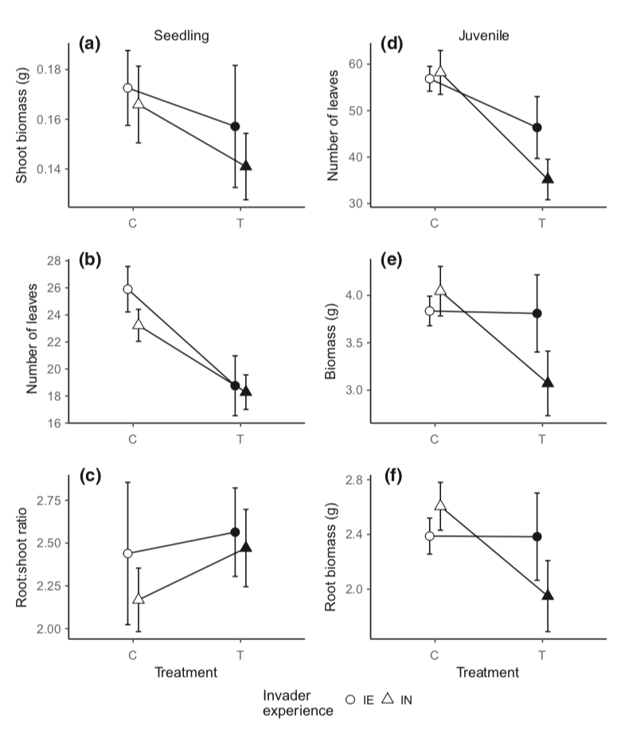

### Fig 1 – repro

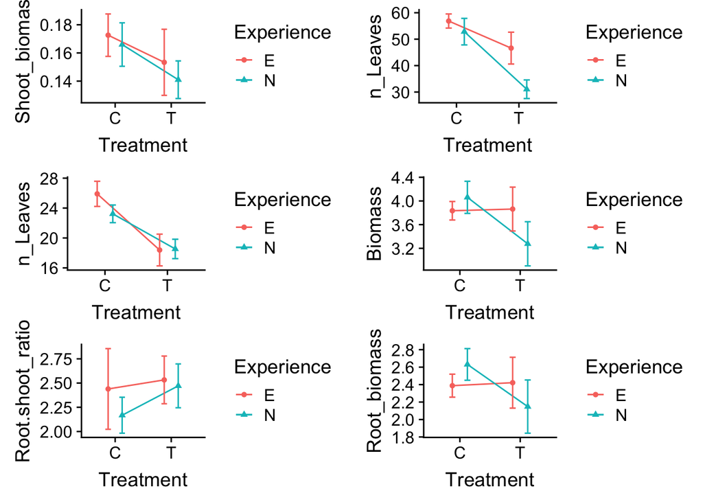

**While the patterns are similar, none reproduce, but this isn’t surprising given that my sample size is bigger than that in Table 1 (so the authors have excluded data, but I’m not sure which).**

## 3.1.1 Seedling

> There was, however, a significant effect of experience type on week-1 rates of germination (F(2, 26) = 9.18, p < .001)

```r
con3 <- list(Treatment=contr.sum, Experience=contr.sum) # change the contrasts coding for the model matrix

# fit.full <- lm(Week_1 ~ Treatment*Experience, data=exp1, contrasts=con3)
# Anova(fit.full, type="3")

# 26 residual df suggests either this was one-way anova with something removed or an additive model
fit.add <- lm(Week_1 ~ Treatment + Experience, data=exp1, contrasts=con3)
Anova(fit.add, type="3") # replicates
```

```
## Anova Table (Type III tests)
##
## Response: Week_1
##             Sum Sq Df F value    Pr(>F)
## (Intercept) 5212.5  1 63.6986 1.849e-08 ***
## Treatment      0.0  1  0.0000 1.0000000
## Experience  1502.3  2  9.1791 0.0009638 ***
## Residuals   2127.6 26
## ---
## Signif. codes:  0 '***' 0.001 '**' 0.01 '*' 0.05 '.' 0.1 ' ' 1
```

```r
# fit.one <- lm(Week_1 ~ Experience, data=exp1[Population!="Ana"])
# anova(fit.one) # obviously cannot be it given Ana is in the posthoc
```

**Reproduces using additive model (not specified in methods)**

> Post hoc tests showed that differences in germination existed between Anatone and the wild populations, but not between IE and IN populations (p = .95). Anatone had 98% fewer week-1 germinants than either IE (difference = 27.8 germinants, p = <.001) or IN populations (difference = 28.7 germinants, p < .001).

```r
fit.emm <- emmeans(fit.add, specs=c("Experience"))
# Tukey HSD
contrast(fit.emm, method="revpairwise")
```

```
##  contrast estimate   SE df t.ratio p.value
##  E - C      27.833 6.91 26 4.029   0.0012
##  N - C      28.688 6.78 26 4.228   0.0007
##  N - E       0.854 3.45 26 0.247   0.9669
##
## Results are averaged over the levels of: Treatment
## P value adjustment: tukey method for comparing a family of 3 estimates
```

```r
# no adjustment
# contrast(fit.emm, method="revpairwise", adjust="none")
```

**There are slight differences in Tukey post-hoc**

> There was no significant effect of competition treatment on week-1 germination (F(1, 26) = 0.002, p = .96).

**Very slight differences (See ANOVA table above) not sure why.**

> Experience type was significant for only one trait (Table 1): average shoot biomass was higher for IE populations (M = 0.17 g, SD = 0.12) than for IN populations (M = 0.15 g, SD = 0.08; Figure 1a).

```r
    xcols <- c("Treatment", "Experience", "Population")
    y <- "Shoot_biomass"
    subdata_i <- subdata(exp2.b, "Seedling", xcols, y)

    # data.table(term="Experience",
    #            response=y,
    #            df=df_table[["Seedling"]][terms=="Experience", get(y)],
    #            F=round(f_table[["Seedling"]][terms=="Experience", get(y)], 2),
    #            p=round(p_table[["Seedling"]][terms=="Experience", get(y)],3))

    fit <- lm(get(y) ~  Treatment + Experience + Population.cross%in%Experience + Treatment:Experience, data=subdata_i)
    (fit.emm <- emmeans(fit, specs=c("Experience")))
    (fit.contrast <- contrast(fit.emm, method="revpairwise"))

    subdata_i[, .(mean=mean(get(y)), sd=sd(get(y))), by=Experience]
```

[output not shown]

**The ANOVA result doesn’t reproduce (Table 1 above). Neither the modeled means (from the fit model) nor the simple means (complete pooling) reproduce but again the authors seem to be using a reduced data set.**

**The repro table has three significant p-values for the experience term (none are shoot_biomass) but again, the experience terms differ from that in JMP (I don’t know which if either are correct)**

> Competition treatment significantly impacted three traits (Table 1): plants grown in pots with C. stoebe had fewer leaves (Figure 1b), shorter leaves (M = 17.9 cm, SD = 4.5 vs. M = 19.5 cm, SD = 5.28) and a higher root:shoot ratio (more allocation to root biomass; Figure 1c) than did plants growing in control pots.

```r
    xcols <- c("Treatment", "Experience", "Population")
    y <- "Longest_leaf"
    subdata_i <- subdata(exp2.b, "Seedling", xcols, y)

    fit <- lm(get(y) ~  Treatment + Experience + Population.cross%in%Experience + Treatment:Experience, data=subdata_i)
    (fit.emm <- emmeans(fit, specs=c("Treatment")))
```

```
## NOTE: A nesting structure was detected in the fitted model:
##     Population.cross %in% Experience
```

```
## NOTE: Results may be misleading due to involvement in interactions
```

```
##  Treatment emmean   SE df lower.CL upper.CL
##  C           22.5 3.08 91     16.4     28.6
##  T           17.8 3.29 91     11.3     24.3
##
## Results are averaged over the levels of: Population.cross, Experience
## Results are given on the get (not the response) scale.
## Confidence level used: 0.95
```

```r
    (fit.contrast <- contrast(fit.emm, method="revpairwise"))
```

```
##  contrast estimate  SE df t.ratio p.value
##  T - C       -4.72 4.5 91 -1.048  0.2972
##
## Results are averaged over the levels of: Population.cross, Experience
```

```r
    subdata_i[, .(mean=mean(get(y)), sd=sd(get(y))), by=Treatment]
```

```
##    Treatment     mean        sd
## 1:         C 23.37273 29.604057
## 2:         T 18.02041  4.497637
```

**ANOVA results do not reproduce (Table 1 above). The means are close for the treated but not really close for the control level. Again, given table 1, the authors are using a smaller dataset.**

**The repro table has only one significant p-value (n_leaves)**

> There were significant interactions of treatment and experience type for number of leaves and root:shoot ratio (Table 1)

**This ANOVA result does not reproduce (Table 1). The repro table has no signficant p-values.**

## 3.1.2 Juvenile

> Experience type was marginally significant for number of leaves (Table 1): compared to IN plants, IE plants had more leaves (M = 52.3, SD = 22.4; vs. M = 51.3; SD = 28.7).

n_leaves has a signficant p-value in the repro table, but again, I cannot get R and JMP to give same result for the Experience term**

> Competition treatment was significant for one of six measured traits and marginally significant for two traits (Table 1): plants growing with C. stoebe had fewer leaves (Figure 1d), and lower total and root biomass (Figure 1e,f) than those growing without competition.

**The repro table does not reproduce but n_leaves does have significant p-value**.

> Population within experience type was significant for five of six variables (Table 1): length of longest leaf, number of leaves, total biomass, root biomass and shoot biomass.

**The published table 1 shows the Population effect signficant in only three (not five) variables. In the repro table, this term has signficant p-values for n_leaves, total biomass, and root biomass.**

> There was a significant interaction between treatment and experience type for biomass and root biomass (Table 1)

**The repro table does not reproduce – there are no variables with a significant p-value for the interaction effect**

## 3.2 Relative Interaction Index

> We used ANOVA to determine whether P. spicata tolerance differed between invasion experience types, with separate models for seedling (RII-Seedling) and juvenile (RII-Juvenile) response variables. We excluded four populations from seedling RII analyses and six from juvenile RII analyses because there were fewer than three plants per population. We also tested for differences in the competitive effect of P. spicata invader experience types on C. stoebe using ANOVA models with C. stoebe suppression (RII-Knapweed) as the response variable. Anatone was not included in the analysis, but we compared the RII values of Anatone to the wild populations.

> Seedlings from IE and IN populations did not differ significantly in their tolerance of C. stoebe (RII-Seedling; F(1, 9) = 0.118, p = .739; Figure 2a,b).

```r
# rii = (b_w - b_a)/(b_w + b_a) # _w=T _a=C
xcols <- c("Treatment", "Experience", "Stage", "Population", "Exp_Pop")
ycols <- c("Longest_leaf", "n_Leaves", "Biomass", "Shoot_biomass", "Root_biomass", "Root.shoot_ratio")

subdata_i <- (exp2[Stage=="Seedling", .SD, .SDcols=c(xcols, "Biomass")])

rii.long <- subdata_i[!is.na(Biomass), .(biomass=mean(Biomass), n=.N), by=.(Treatment, Experience, Population)]
rii.1 <- rii.long[Treatment=="C",]
rii.2 <- rii.long[Treatment=="T",]
rii.wide <- merge(rii.1, rii.2, by=c("Population", "Experience"))
rii.wide[, rii:=(biomass.y - biomass.x)/(biomass.y + biomass.x)]
fit <- lm(rii ~ Experience, data=rii.wide)
anova(fit)
```

```
## Analysis of Variance Table
##
## Response: rii
##            Df  Sum Sq  Mean Sq F value Pr(>F)
## Experience  1 0.00077 0.000772  0.0108 0.9196
## Residuals   9 0.64548 0.071720
```

```r
# fig 2
rii.raw <- rii.wide[, .(rii=mean(rii), SE=sd(rii)/sqrt(.N)), by=Experience]
gg_2b <- ggplot(rii.raw, aes(x=Experience, y=rii)) +
  geom_point() +
  geom_errorbar(aes(ymin=rii-SE, ymax=rii+SE), width=0.2)
```

**F does not reproduce (df does).**

> There was also no difference between juvenile invader experience types in their tolerance (RII-Juvenile; F(1, 9) = 1.61, p = .23; Figure 2c,d)

```r
# rii = (b_w - b_a)/(b_w + b_a) # _w=T _a=C
xcols <- c("Treatment", "Experience", "Stage", "Population", "Exp_Pop")
ycols <- c("Longest_leaf", "n_Leaves", "Biomass", "Shoot_biomass", "Root_biomass", "Root.shoot_ratio")

subdata_i <- (exp2[Stage=="Juvenile", .SD, .SDcols=c(xcols, "Biomass")])

rii.long <- subdata_i[!is.na(Biomass), .(biomass=mean(Biomass), n=.N), by=.(Treatment, Experience, Population)]
rii.long <- rii.long[n >=3, ]
rii.1 <- rii.long[Treatment=="C",]
rii.2 <- rii.long[Treatment=="T",]
rii.wide <- merge(rii.1, rii.2, by=c("Population", "Experience"))
rii.wide[, rii:=(biomass.y - biomass.x)/(biomass.y + biomass.x)]
fit <- lm(rii ~ Experience, data=rii.wide)
anova(fit)
```

```
## Analysis of Variance Table
##
## Response: rii
##            Df  Sum Sq  Mean Sq F value Pr(>F)
## Experience  1 0.12960 0.129605  6.7126 0.0359 *
## Residuals   7 0.13515 0.019308
## ---
## Signif. codes:  0 '***' 0.001 '**' 0.01 '*' 0.05 '.' 0.1 ' ' 1
```

```r
# fig 2
rii.raw <- rii.wide[, .(rii=mean(rii), SE=sd(rii)/sqrt(.N)), by=Experience]
gg_2d <- ggplot(rii.raw, aes(x=Experience, y=rii)) +
  geom_point() +
  geom_errorbar(aes(ymin=rii-SE, ymax=rii+SE), width=0.2)
```

Note the published methods state “We excluded … six [populations] from juvenile RII analyses because there were fewer than three plants per population”. My analysis excluded the populations in which one cell (T or C) had $n < 3$.

```r
# must have the subdata_i using "Juvenile"
rii.long <- subdata_i[!is.na(Biomass), .(biomass=mean(Biomass), n=.N), by=.(Treatment, Experience, Population)]
rii.1 <- rii.long[Treatment=="C",]
rii.2 <- rii.long[Treatment=="T",]
rii.wide <- merge(rii.1, rii.2, by=c("Population", "Experience"))
rii.wide[, rii:=(biomass.y - biomass.x)/(biomass.y + biomass.x)]
rii.wide
```

```
##     Population Experience Treatment.x biomass.x n.x Treatment.y biomass.y
##  1:        Ana          N           C    2.6220   5           T  0.979000
##  2:        BLK          E           C    3.9882   5           T  3.124333
##  3:        BLP          N           C    2.2258   5           T  2.176000
##  4:         HP          N           C    3.9416   5           T  2.966000
##  5:        LHK          E           C    4.2334   5           T  4.378500
##  6:        LHP          N           C    4.4514   5           T  3.468800
##  7:      LHP#1          N           C    3.9976   5           T  3.646000
##  8:       LNFK          E           C    3.2608   5           T  3.644400
##  9:       MCLK          E           C    4.0794   5           T  3.828000
## 10:        MJP          N           C    3.7724   5           T  5.128000
## 11:        MMK          E           C    3.3690   5           T  2.954600
## 12:        MMP          N           C    4.0788   5           T  2.654400
## 13:        PTK          E           C    4.0778   5           T  6.172333
## 14:        PTP          N           C    5.8370   5           T  4.597000
##     n.y         rii
##  1:   3 -0.45626215
##  2:   3 -0.12145696
##  3:   1 -0.01131355
##  4:   5 -0.14123574
##  5:   2  0.01684878
##  6:   5 -0.12406252
##  7:   1 -0.04599927
##  8:   5  0.05555234
##  9:   3 -0.03179300
## 10:   2  0.15230776
## 11:   5 -0.06553229
## 12:   5 -0.21154874
## 13:   3  0.20434206
## 14:   1 -0.11884225
```

The published figure (and presumably ANOVA) (see Fig 2c below) excluded LHK, which has n=5 (Control) and n=2 (Treated) (so is also excluded in the repro) but did not exclude, for example, BLP or PTP, both have n=5 (Control) and n=1 (Treated) (both excluded in my repro). That is, it is not clear what criteria the authors used to exclude populations, but is not my interpretation of what the authors report they did.

```r
# starting with rii.wide of juvenile keeping all pops

excl <- c("LHK", "LHP#1", "MCLP", "MJP")
all_pops <- unique(exp2$Population)
incl <- setdiff(all_pops, excl)
rii.wide.pub <- rii.wide[Population %in% incl]

fit <- lm(rii ~ Experience, data=rii.wide.pub)
anova(fit)
fit <- lm(rii ~ Experience, data=rii.wide.pub[Population != "Ana"])
anova(fit)

# fig 2 - based on published fig 2d, Ana is excluded
rii.raw <- rii.wide.pub[Population != "Ana", .(rii=mean(rii), SE=sd(rii)/sqrt(.N)), by=Experience]
gg_2d <- ggplot(rii.raw, aes(x=Experience, y=rii)) +
  geom_point() +
  geom_errorbar(aes(ymin=rii-SE, ymax=rii+SE), width=0.2)
```

[output not shown]

### Supression

**I don’t see the data for C. stoebe biomass so cannot compute index of supression.**

## Fig 2

### Fig 2 – published

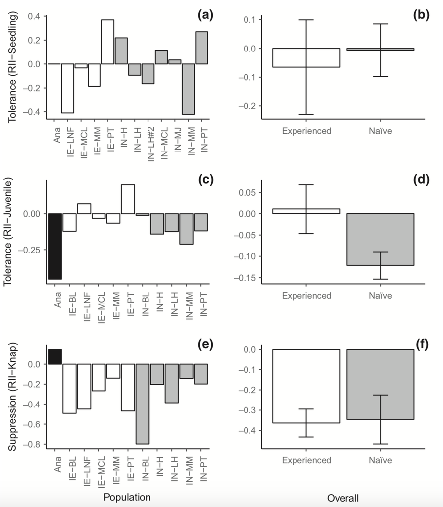

### Fig 2 repro

[figure not shown]

# Statistical red flags

1. It is not clear why the authors treat Population as a fixed effect.
2. The reported F for the Treatment effect on root:shoot response for Seedling is 100.97. Two red-flags about this value. 1) The effect relative to the SE in Fig 1 does not look big enough to gemerate this F. That said, it can be very hard to mentally compute F especially given the nested structure of the design. 2) The F for both root biomass and shoot biomass is very small and root:shoot is just the ratio of these. If there is a large effect with root:shoot there must be some noticeable effect with either root or shoot or both.